# Uvod u R

[GitHub repozitorijum](https://github.com/milankili/AnalizaProstornoVremenskihPodataka)

Milan Kilibarda

Analiza prostorno vremenskih podataka - Master studije geoinformatike, Građevinski fakultet u Beogradu

2026-05-20

## Sadrzaj

- **Deo I:** Osnovno o R-u?
- **Deo II:** Uvod u sintaksu R programskog jezika
- **Deo III:** R paketi
- **Deo IV:** Tipovi i strukture podataka u R-u
- **Deo V:** R jezik

## Infografik

[figure not shown]

## Pregledani video

[video not shown]

# Deo I: Osnovno o R-u

## Zašto R?

- 🚀 **Moćan statistički alat:** R je programski jezik, inicijalno namenjen statističkom računanju i vizualizaciji podataka.
- 🌍 **Besplatan i otvorenog koda:** `Free and open source` okruženje dostupno na različitim platformama.
- 🤝 **Aktivna zajednica:** Fantastična podrška kroz [#rstats zajednicu na Twitter-u](https://twitter.com/search?q=%23rstats) i [Stack Overflow](https://stackoverflow.com/questions/tagged/r).
- 📦 **Proširivo okruženje:** Mnoštvo dostupnih paketa za različite oblasti - pogledaj [CRAN Task View](https://cran.r-project.org/web/views/).
- 🎓 **Akademska prihvaćenost:** R je široko prihvaćen u akademskoj zajednici za istraživanja i nastavu.
- 📈 **Brz rast:** Jedan od najbrže rastućih programskih jezika u svetu podataka.
- 🗺️ **Rad sa prostornim podacima:** Jedna od ključnih oblasti razvoja, sa snažnim paketima za GIS analize.

## R okruzenje

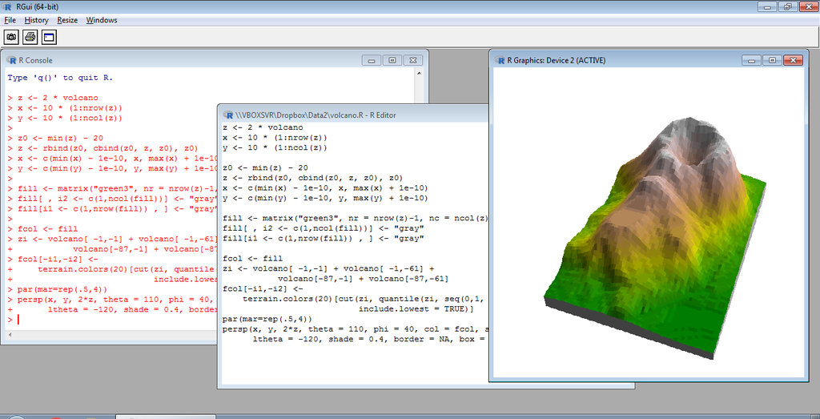

R GUI

## R-studio

[figure not shown]

# Deo II: Uvod u sintaksu R programskog jezika

## Aritmetičke operacije

### Aritmetičke operacije

| Operator | Značenje |
| --- | --- |
| `+` | Sabiranje |
| `-` | Oduzimanje |
| `*` | Množenje |
| `/` | Deljenje |
| `^` | Stepenovanje |

### Primeri

```r
5 + 3
```

```
[1] 8
```

```r
1 * 10
```

```
[1] 10
```

```r
10^2
```

```
[1] 100
```

## Specijalne vrednosti

### Specijalne vrednosti

| Value | Znacenje |
| --- | --- |
| `Inf` | Infinity |
| `NA` | Not Available |
| `NaN` | Not a Number |
| `NULL` | Empty object |

### Primeri specijalnih vrednosti

```r
1/0
```

```
[1] Inf
```

```r
NA + 3
```

```
[1] NA
```

```r
NA == 1
```

```
[1] NA
```

```r
0/0
```

```
[1] NaN
```

```r
NULL
```

## Logički operatori i specijalne vrednosti

### Logički operatori

[output not shown]

### Primeri

```r
1 < 2
```

```
[1] TRUE
```

```r
2 >= 2
```

```
[1] TRUE
```

```r
2 != 2
```

```
[1] FALSE
```

## Objekti i promenljive u R-u

- 🗂️ **Objektno-orijentisan jezik:** R je objektno-orijentisan programski jezik namenjen radu sa podacima.
- 📦 **Podaci kao objekti:** Svi podaci i funkcije čuvaju se u okviru R objekata.
- 🏷️ **Promenljive kao objekti:** Svaku promenljivu možemo smatrati objektom, tj. naziv/ime pod kojim skladištimo i pozivamo određene podatke.
- 🔗 **Dodeljivanje vrednosti:** Za dodeljivanje imena promenljivoj koristi se operator `<-` ili `=`.

### 📊 Primer:

```r
die <- 1:6  # Skladištenje niza brojeva od 1 do 6

die         # Pozivanje promenljive "die"
```

```
[1] 1 2 3 4 5 6
```

- 🔢 **Operator `:`:** Koristi se za kreiranje vektora brojeva u obliku `od:do` (npr. `1:6`).
- 📝 **Komentari:** `#` služi za komentarisanje koda. Sve što stoji desno od znaka `#` neće se izvršavati.

## R je **`case sensitive`**

### 💡 Napomena:

Promenljive u R-u su osetljive na veličinu slova (`Case Sensitive`), pa su `Promenljiva` i `promenljiva` dve različite promenljive.

```r
Name <- 1
name <- 0
Name + 1
```

```
[1] 2
```

Svi kreirani objekti se skladište u ovkiru radnog okruženja i mogu se pregledati komandom `ls()`:

```r
ls()
```

```
[1] "die"             "name"            "Name"            "pandoc_dir"
[5] "quarto_bin_path"
```

Uklanjanje odredenog objekta iz radnog okruženja/memorije vrši se komandom `rm()`:

```r
rm(Name)
```

## 📊 Funkcije u R-u

- 🔢 **Matematičke funkcije:** Osnovna instalacija R-a sadrži glavne matematičke funkcije:

```r
round(3.1415)    # Zaokruživanje broja
```

```
[1] 3
```

```r
factorial(3)     # Faktorijel broja 3
```

```
[1] 6
```

```r
pi               # Pozivanje konstante π
```

```
[1] 3.141593
```

```r
sin(pi/2)        # Sinus od π/2
```

```
[1] 1
```

### 💡 Napomena:

- `round()` zaokružuje brojeve.
- `factorial()` računa faktorijel.
- `pi` vraća vrednost broja π.
- `sin()` izračunava sinus.

## 📊 Funkcije u R-u - simulacija bacanja kocke

- 🎲 **Simulacija bacanja kockice:** Funkcija `sample` omogućava nasumično biranje elemenata.

```r
die <- 1:6                     # Definisanje vektora (kockica sa 6 strana)
sample(x = die, size = 1)      # Nasumično biranje jednog broja
```

```
[1] 4
```

### 💡 Napomena:

- `sample()` služi za uzorkovanje iz vektora.

## ❔Help

Jedna od veoma korisnih mogućnosti R programskog okruženja je brz i jednostavan uvid u dokumentaciju za određene funkcije, putem komande `help`. Na primer, da biste saznali više o funkciji `sample`, jednostavno pozovite:

- Pozivanje komande `?sample` otvara pomoćni prozor sa svim relevantnim informacijama o funkciji.
- Ova komanda uključuje opis funkcije, argumente, primene i slične funkcije.

```r
?sample
```

## 📊 Kreiranje sopstvene funkcije u R-u

Funkcije su osnovni gradivni blokovi R programskog jezika. Omogućavaju nam da organizujemo kod, izbegnemo ponavljanje i povećamo efikasnost.

### Šta je funkcija?

Funkcija je blok koda koji izvršava određeni zadatak.

Sastoji se od:

- **Imena** (naziv funkcije)
- **Argumenata** (ulazni podaci)
- **Tela** (kod koji se izvršava)
- **Povratne vrednosti** (rezultat funkcije)

## Sintaksa funkcije

Funkcija se kreira pomoću ključne reči `function()` i vitičastih zagrada `{}`:

```
ime_funkcije <- function(argumenti) {
  # Telo funkcije
  return(rezultat)  # Povratna vrednost
}
```

Na primer, funkcija koja simulira bacanje dve kockice i sumiranje rezultata se može kreirati na sledeci nacin:

```r
roll <- function() {
  die <- 1:6
  dice <- sample(die, size = 2, replace = TRUE)
  sum(dice)
}
roll()
```

```
[1] 11
```

#### Ključne napomene:

- Ova funkcija nema argumente – koristi fiksne vrednosti.
- Funkcija `sample()` služi za nasumično uzorkovanje.
- Argument `replace = TRUE` omogućava ponavljanje vrednosti.

## Argumenti funkcije

Argumenti funkcije su promenljive od kojih zavisi rezultat izvršavanja funkcije, i definišu se u okviru operatora **`function()`**.

Na primer, zamislimo da kockica nema vrednosti od 1 do 6, nego proizvoljnih šest vrednosti koje su definisane pravilima igre. U tom slučaju, mora se ostaviti mogućnost za definisanje vrednosti.

```r
roll2 <- function(dice) {
  dice <- sample(dice, size = 2, replace = TRUE)
  sum_dice <- sum(dice)
  return(sum_dice) #  povratna vrednost
}

roll2(dice = 2:8) # bacanje 2 kockice koje imaju vrednosti od 2 do 8, ne 1 do 6
```

```
[1] 13
```

# 📦Poglavlje III: R paketi

## 📦 R Paketi

R paketi su osnova R ekosistema. Oni omogućavaju proširivanje funkcionalnosti R-a za različite tematske oblasti.

### Šta su R paketi?

- **Set funkcija:** Kreirani od strane korisnika za rešavanje specifičnih zadataka.
- **Dokumentacija:** Uključuju `help` dokumentaciju i primere korišćenja.
- **Podaci:** Često sadrže i male setove podataka za demonstraciju.

### Broj R paketa

- Do danas, na **CRAN**-u (Centralni R Arhiv) postoji preko **20000** paketa.
- [CRAN Task View](https://cran.r-project.org/web/views/) pruža pregled paketa po tematskim oblastima.
- Još mnostvo R paketa je dostupno u svojoj razvojnoj verziji na web repozitorijumima (**`github`**)

## Instalacija R paketa

- Paketi se instaliraju pozivom komande **`install.packages()`**
- Instaliranje paketa znači njegovo smestanje u memoriji racunara, na odredenoj lokaciji, odnosno folderu kojeg nazivamo **`library`**.
- Da bi funkcije određenog paketa bile dostupne prilikom rada, neophodno ga je učitati paket u radno oruženje, odnosno u radnu sesiju komandom **`library()`**.

Primer instaliranja i učitavanja paketa **`readxl`**:

```r
install.packages("readxl")
library(readxl)
```

- Paket **`readxl`** omogućava funkcije za lako i brzo učitavanje `excel` fajlova.

# Poglavlje IV: Tipovi i strukture podataka u R-u

## Vektori 1️⃣2️⃣3️⃣4️⃣

- Vektor je osnovna i najjednostavnija struktura podataka u R-u
- Osnovna karakteristika vektora je da sadrži samo podatke istog tipa.
- R razlikuje šest osnovnih tipova podataka:

| Tip | Test | Konverzija |
| --- | --- | --- |
| **double** | is.double | as.double |
| **integer** | is.integer | as.integer |
| **character** | is.character | as.character |
| **logical** | is.logical | as.logical |
| **complex** | is.complex | as.complex |
| **raw** | is.raw | as.raw |

- **`is.vector`** je komanda koja se koristi za test-proveru da li je određeni objekat vektor.

## Primeri kreiranja različitih tipova vektora

```r
die <- c(1, 2, 3, 4, 5, 6)
die <- 1:6
die <- seq(1, 6, 1)
typeof(die)
```

```
[1] "double"
```

```r
int <- c(-1L, 2L, 4L)
typeof(int)
```

```
[1] "integer"
```

```r
text <- c("Geodezija",  "Geoinformatika")
typeof(text)
```

```
[1] "character"
```

```r
3 > 4
```

```
[1] FALSE
```

```r
logic <- c(TRUE, FALSE, TRUE)
typeof(logic)
```

```
[1] "logical"
```

```r
typeof(F)
```

```
[1] "logical"
```

```r
vec <- c(1, 2, 3, NA)
is.na(vec)
```

```
[1] FALSE FALSE FALSE  TRUE
```

## Konverzija tipova podataka (Coercion)

- Konverzija tipova podataka se npr. dešava kada se u jednom vektoru (ili matrici) nađu podaci razlicitih tipova.
- U tom slucaju R automatski sve podatke svodi na jedan tip po određenom pravilu.

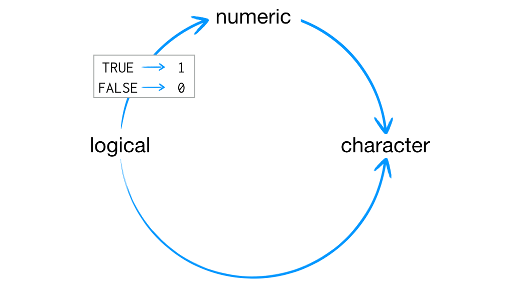

Pravilo konverzije tipova podataka u R-u

## Element-wise procedura kod vektora

Element-wise operacije omogućavaju primenu funkcije ili operatora na svaki element vektora ili matrice pojedinačno.

U R-u, mnoge funkcije su optimizovane da automatski primenjuju operacije na svaki element objekta bez potrebe za eksplicitnim petljama.

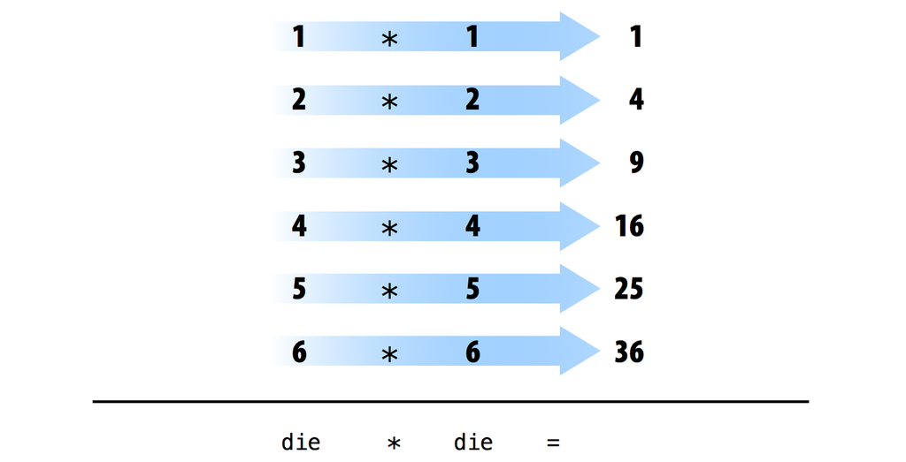

Element wise procedura

## Vector Recycling

Vector recycling je procedura u R-u koja omogućava automatsko ponavljanje kraćih vektora kako bi odgovarali dužini dužih vektora prilikom primene operacija između vektora različitih dužina.

[figure not shown]

Vector recycling procedura

## Atributi

- Atribut je informacija koju možemo dodeliti vektoru (ili bilo kojem R objektu).
- Atribut neće uticati na vrednosti objekta i neće se prikazivati kada prikazujemo objekat.
- Postojanje atributa vezanih za neki objekat može se proveriti funkcijom **`attributes()`**.
- Međutim, postojanje određenih/specijalnih atributa vezanih za neki objekat može uticati na to kako će određena funkcija tretirati taj objekat.

### Primer: Provera atributa

Postavimo primer objekta `die` i proverimo njegove atribute.

```r
# Definisanje vektora
die <- 1:6

# Provera atributa objekta 'die'
attributes(die)
```

## Atributi

- Najcesće korišćeni atributi su: `names`, `dimensions` i `classes`.

```r
die <- 1:6
names(die)
```

```r
names(die) <- c("one", "two", "three", "four", "five", "six")
names(die)
```

```
[1] "one"   "two"   "three" "four"  "five"  "six"
```

```r
attributes(die)
```

```
$names
[1] "one"   "two"   "three" "four"  "five"  "six"
```

```r
die + 1 # atributi ne uticu na vrednosti
```

```
  one   two three  four  five   six
    2     3     4     5     6     7
```

## Atributi (`dimensions` i `class`)

- Dodavanje atributa `dimensions` vrši se komandom **`dim()`**.
- U ovom primeru, jedno-dimenzionalni objekat (vektor) se transformiše u dvo-dimenzionalnu strukturu (matricu), čime se menja i drugi atribut **`class`**.

```r
dim(die) <- c(2, 3)
class(die)
```

```
[1] "matrix" "array"
```

- Kao što je rečeno ranije, atributi mogu uticati na to kako ce se određene funkcije odnositi prema tom objektu.
- Tako na primer, promena atributa `class`, uticaće na komandu `print` koja se izvrsava u pozadini kada želimo prikazati objekat na ekranu.

```r
die
```

```
     [,1] [,2] [,3]
[1,]    1    3    5
[2,]    2    4    6
```

## Atributi (`Dates` i `times`)

- Postojanje atributa **`class`** omogućava predstavljanje dodatnih tipova podataka, koji su različiti od osnovnih tipova kao što su **`double`**, **`integer`**, **`character`** itd.
- Karakterističan primer je skladištenje informacija o vremenu koristeći **`POSIXct`** klasu, koja predstavlja datum i vreme kao broj sekundi koje su protekle od **1. januara 1970. godine**.

```r
vreme.sad <- Sys.time()
vreme.sad
```

```
[1] "2026-04-22 09:40:08 CEST"
```

```r
typeof(vreme.sad)
```

```
[1] "double"
```

```r
class(vreme.sad)
```

```
[1] "POSIXct" "POSIXt"
```

## Faktorski podaci u R-u

Faktorski podaci su posebna vrsta podataka u R-u koji se koriste za predstavljanje kategoričkih promenljivih.

### Šta su faktorski podaci?

- **Kategoričke promenljive:** Predstavljaju grupe ili kategorije (npr. pol, boja, nivo obrazovanja).
- **Fiksni nivoi:** Imaju unapred definisane vrednosti (nivoi).
- **Interno kodirani:** R čuva faktore kao celobrojne vrednosti sa pridruženim labelama.

### Kreiranje faktora

Faktori se kreiraju pomoću funkcije `factor()`.

```r
# Primer: Faktor za predstavljanje polova
pol <- factor(c("muško", "žensko", "muško", "žensko"))
pol
```

```
[1] muško  žensko muško  žensko
Levels: muško žensko
```

## 🔢 Matrice

Matrice su dvo-dimenzionalne strukture u R-u koje skladište podatke u redovima i kolonama.

### Kreiranje matrica

Matrice se kreiraju pomoću funkcije `matrix()`. Ključni argumenti su:

- `nrow` – broj redova
- `ncol` – broj kolona
- `byrow = TRUE/FALSE` – način popunjavanja (po redovima ili kolonama)

```r
# Definisanje niza vrednosti
die <- c(1, 2, 3, 4, 5, 6)

# Kreiranje matrice sa popunjavanjem po kolonama
m1 <- matrix(die, ncol  = 2)
print(m1)
```

```
     [,1] [,2]
[1,]    1    4
[2,]    2    5
[3,]    3    6
```

```r
# Kreiranje matrice sa popunjavanjem po redovima
m2 <- matrix(die, nrow = 2, byrow = TRUE)
print(m2)
```

```
     [,1] [,2] [,3]
[1,]    1    2    3
[2,]    4    5    6
```

## Nizovi (Arrays) 🔢 🔢 🔢

Nizovi (*arrays*) su **n-dimenzionalne strukture podataka** u R-u koje proširuju koncept matrica na više dimenzija.

### 🏗 Struktura nizova

- Možemo ih zamisliti kao **skup matrica** poređanih duž dodatne dimenzije.
- Svaka matrica može predstavljati jedan **set podataka** prikupljen u određenom trenutku ili na određenom mestu.
- Često se koriste u **analizi vremenskih serija**, obradi slika i GIS podacima.

### 🎨 Primena nizova

- **RGB fotografije** se mogu predstaviti kao trodimenzionalni niz gde svaki sloj matrice sadrži vrednosti refleksije za **R (crvenu)**, **G (zelenu)** i **B (plavu) komponentu**.
- **Multispektralne slike** sa satelita mogu sadržavati **10+ slojeva**, gde svaki sloj odgovara refleksiji na različitoj **talasnoj dužini**.

## 🛠 Kreiranje nizova

Nizovi se kreiraju pomoću funkcije `array()`.

Ključni argumenti su:

- `data` – ulazni podaci (vektor koji će se oblikovati u niz)

- `dim` – dimenzije niza (broj redova, kolona i dodatnih slojeva)

### Primer kreiranja niza

```r
# Kreiranje 3x3x2 niza (2 sloja matrica 3x3)
data <- 1:18
dim <- c(3, 3, 2)  # 3 reda, 3 kolone, 2 sloja
array_data <- array(data, dim = dim)
```

```r
print(array_data)
```

```
, , 1

     [,1] [,2] [,3]
[1,]    1    4    7
[2,]    2    5    8
[3,]    3    6    9

, , 2

     [,1] [,2] [,3]
[1,]   10   13   16
[2,]   11   14   17
[3,]   12   15   18
```

## Liste 📦

Liste su **jednodimenzionalne strukture podataka** u R-u koje mogu sadržavati **objekte različitih tipova**.

### 🔑 Ključne osobine lista:

- ✅ Slično vektorima, liste grupišu podatke u jedan objekat.
- ✅ **Za razliku od vektora**, elementi liste mogu biti **različitih tipova** (brojevi, tekst, logičke vrednosti, pa čak i druge liste).
- ✅ Često se koriste za **skladištenje rezultata analize** ili podataka različitih struktura.

## 🛠 Kreiranje liste

Liste se kreiraju pomoću funkcije `list()`.

```r
# Kreiranje liste sa različitim tipovima podataka
num <- c(1,2,3,4,5,6)         # Numerički vektor
int <- c(10L, 20L, 30L)       # Celi brojevi (integer)
text <- c("Geodezija", "Geoinformatika")  # Tekstualni vektor
logic <- c(TRUE, FALSE, TRUE) # Logičke vrednosti (boolean)

lista <- list(num, int, text, logic)
```

```r
lista
```

```
[[1]]
[1] 1 2 3 4 5 6

[[2]]
[1] 10 20 30

[[3]]
[1] "Geodezija"      "Geoinformatika"

[[4]]
[1]  TRUE FALSE  TRUE
```

## Data Frame 📊

**`Data Frame`** je **tabelarna struktura podataka** u R-u koja skladišti **vektore iste dužine** u kolonama.

### 🔑 Ključne osobine `Data Frame`-a:

- ✅ **Slično Excel tabelama** – koristi se za skladištenje podataka u redovima i kolonama.
- ✅ **Kolone mogu biti različitih tipova** (brojevi, tekst, logičke vrednosti).
- ✅ **Dvo-dimenzionalna verzija liste** – svaka kolona može biti različitog tipa, ali **svi vektori moraju imati istu dužinu**.
- ✅ **Najčešće korišćena struktura podataka** u **statistici, GIS-u, analizi podataka i mašinskom učenju**.

## Data Frame Primer 📊

U R-u, `Data Frame` može biti kreiran čak i kada **ulazni vektori nisu iste dužine**.  
U tom slučaju, R primenjuje **“element recycling”**, tj. **ponavlja kraće vektore dok ne dostignu dužinu najdužeg vektora**.

```r
# Definisanje vektora različitih dužina
num <- c(1, 2, 3, 4, 5, 6)      # 6 elemenata
int <- c(10L, 20L, 30L)         # 3 elementa
text <- c("Geo", "Info")        # 2 elementa
logic <- c(TRUE, FALSE, TRUE)   # 3 elementa

# Kreiranje Data Frame-a
dataframe <- data.frame(numeric = num,
                        integer = int,
                        tekst = text,
                        logic = logic)
```

```r
# Prikaz formiranog Data Frame-a
dataframe
```

```
  numeric integer tekst logic
1       1      10   Geo  TRUE
2       2      20  Info FALSE
3       3      30   Geo  TRUE
4       4      10  Info  TRUE
5       5      20   Geo FALSE
6       6      30  Info  TRUE
```

## Sumarno o strukturama podataka u R-u

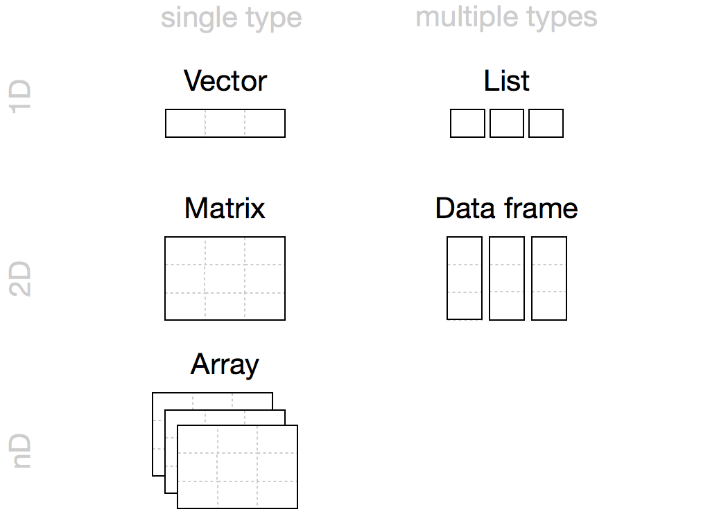

Strukture podataka u R-u

## Komanda `str()` 🔍

Komanda **`str()`** omogućava brz **pregled strukture** R objekta.  
Koristi se za **ispitivanje tipova podataka**, broja elemenata i organizacije objekta.

### 🛠 Primer upotrebe `str()`

```r
# Pregled strukture Data Frame-a
str(dataframe)
```

```
'data.frame':   6 obs. of  4 variables:
 $ numeric: num  1 2 3 4 5 6
 $ integer: int  10 20 30 10 20 30
 $ tekst  : chr  "Geo" "Info" "Geo" "Info" ...
 $ logic  : logi  TRUE FALSE TRUE TRUE FALSE TRUE
```

# Poglavlje V: R jezik

## Izdvajanje (selektovanje) vrednosti podataka 🎯

U R-u postoji **šest različitih načina izdvajanja vrednosti podataka**,  
a koriste se **tri operatora** za selektovanje elemenata:

- **`[[`** – koristi se za liste i data frame-ove (vraća direktnu vrednost)
- **`[`** – koristi se za vektore, matrice i data frame-ove (vraća podskup)
- **`$`** – koristi se za izdvajanje kolona iz `Data Frame`-a i listi po nazivu

## Izdvajanje vrednosti vektora 🎯

U R-u možemo izdvajati vrednosti iz vektora koristeći **pozitivne celobrojne indekse**.  
Indeksiranje **uvek počinje od 1** (za razliku od nekih drugih jezika kao što su Python i C, gde kreće od 0).

### 🛠 Primer izdvajanja vrednosti

```r
# Definisanje vektora
x <- c(2.1, 4.2, 3.3, 5.4)

# 1. Izbor specifičnih elemenata (3. i 1.)
x[c(3, 1)]
```

```
[1] 3.3 2.1
```

```r
# 2. Sortirano indeksiranje (vraća sortirani vektor)
x[order(x)]
```

```
[1] 2.1 3.3 4.2 5.4
```

```r
# 3. Ponovljeni indeks (pristup istom elementu više puta)
x[c(1, 1)]
```

```
[1] 2.1 2.1
```

```r
# 4. Korišćenje decimalnih brojeva (automatsko zaokruživanje)
x[c(2.1, 2.9)]  # U pozadini se svodi na x[c(2, 2)]
```

```
[1] 4.2 4.2
```

## Izdvajanje vrednosti vektora 🎯

U R-u možemo izdvajati vrednosti vektora koristeći **negativne celobrojne indekse** i **logičke vrednosti**.

### 🚫 Izdvajanje negativnim indeksima

Kada koristimo **negativne indekse**, iz vektora **isključujemo** određene elemente, dok ostale zadržavamo.

```r
# Definisanje vektora
x <- c(2.1, 4.2, 3.3, 5.4)

# Isključivanje prvog elementa, ostali ostaju
x[-1]
```

```
[1] 4.2 3.3 5.4
```

```r
# Isključivanje trećeg i prvog elementa
x[-c(3, 1)]
```

```
[1] 4.2 5.4
```

```r
# Logički vektor određuje koje vrednosti će biti uključene
x[c(TRUE, TRUE, FALSE, FALSE)]
```

```
[1] 2.1 4.2
```

```r
# Izdvajanje vrednosti većih od 3
x[x > 3]
```

```
[1] 4.2 3.3 5.4
```

## 🎯 Izdvajanje vrednosti Data frame-a

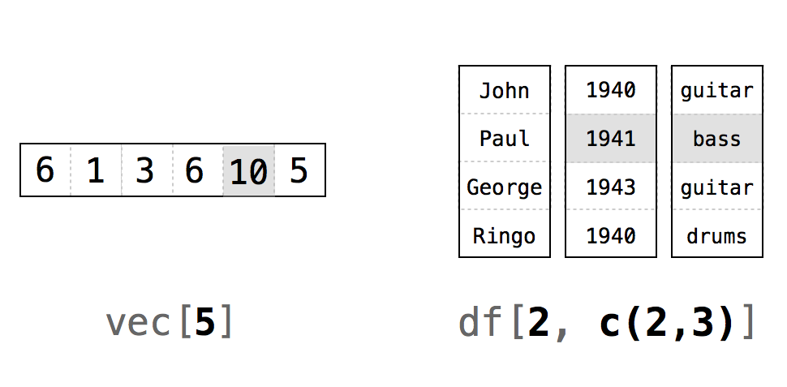

Izdvajanje vrednosti vektora i data frame-a celobrojnim vektorima

## 📋 Izdvajanje redova iz Data Frame-a

```r
# Učitavanje ugrađenog Data Frame-a 'mtcars'
data(mtcars)

# Izdvajanje prvih 10 redova
mtcars[1:10, ]
```

```
                   mpg cyl  disp  hp drat    wt  qsec vs am gear carb
Mazda RX4         21.0   6 160.0 110 3.90 2.620 16.46  0  1    4    4
Mazda RX4 Wag     21.0   6 160.0 110 3.90 2.875 17.02  0  1    4    4
Datsun 710        22.8   4 108.0  93 3.85 2.320 18.61  1  1    4    1
Hornet 4 Drive    21.4   6 258.0 110 3.08 3.215 19.44  1  0    3    1
Hornet Sportabout 18.7   8 360.0 175 3.15 3.440 17.02  0  0    3    2
Valiant           18.1   6 225.0 105 2.76 3.460 20.22  1  0    3    1
Duster 360        14.3   8 360.0 245 3.21 3.570 15.84  0  0    3    4
Merc 240D         24.4   4 146.7  62 3.69 3.190 20.00  1  0    4    2
Merc 230          22.8   4 140.8  95 3.92 3.150 22.90  1  0    4    2
Merc 280          19.2   6 167.6 123 3.92 3.440 18.30  1  0    4    4
```

🔹 **Napomena:**  
- `mtcars[1:10, ]` selektuje prvih **10 redova**, dok se sve kolone zadržavaju.  
- Ako želimo **samo određene kolone**, dodajemo selektor za kolone (`mtcars[1:10, c("mpg", "hp")]`).

## 🔍 Prikaz prvih redova Data Frame-a

```r
data(mtcars)

# Prikaz prvih n redova (podrazumevano 6)
head(mtcars)
```

```
                   mpg cyl disp  hp drat    wt  qsec vs am gear carb
Mazda RX4         21.0   6  160 110 3.90 2.620 16.46  0  1    4    4
Mazda RX4 Wag     21.0   6  160 110 3.90 2.875 17.02  0  1    4    4
Datsun 710        22.8   4  108  93 3.85 2.320 18.61  1  1    4    1
Hornet 4 Drive    21.4   6  258 110 3.08 3.215 19.44  1  0    3    1
Hornet Sportabout 18.7   8  360 175 3.15 3.440 17.02  0  0    3    2
Valiant           18.1   6  225 105 2.76 3.460 20.22  1  0    3    1
```

```r
# Izdvajanje prvih 10 redova
mtcars[1:10, ]
```

```
                   mpg cyl  disp  hp drat    wt  qsec vs am gear carb
Mazda RX4         21.0   6 160.0 110 3.90 2.620 16.46  0  1    4    4
Mazda RX4 Wag     21.0   6 160.0 110 3.90 2.875 17.02  0  1    4    4
Datsun 710        22.8   4 108.0  93 3.85 2.320 18.61  1  1    4    1
Hornet 4 Drive    21.4   6 258.0 110 3.08 3.215 19.44  1  0    3    1
Hornet Sportabout 18.7   8 360.0 175 3.15 3.440 17.02  0  0    3    2
Valiant           18.1   6 225.0 105 2.76 3.460 20.22  1  0    3    1
Duster 360        14.3   8 360.0 245 3.21 3.570 15.84  0  0    3    4
Merc 240D         24.4   4 146.7  62 3.69 3.190 20.00  1  0    4    2
Merc 230          22.8   4 140.8  95 3.92 3.150 22.90  1  0    4    2
Merc 280          19.2   6 167.6 123 3.92 3.440 18.30  1  0    4    4
```

🔹 **Napomena:**  
- `head(mtcars)` prikazuje **prvih 6 redova** bez potrebe za ručnim indeksiranjem.  
- Možemo koristiti `head(mtcars, n = 10)` za prikaz **prvih 10 redova**.

## 🏷️ Razlika između vektora i Data Frame-a pri selektovanju

```r
# Selekcija prve kolone (kao vektor)
a <- mtcars[1:10, 1]
class(a)  # Vratiće "numeric"
```

```
[1] "numeric"
```

```r
# Selekcija prve kolone, ali zadržavajući Data Frame strukturu
b <- mtcars[1:10, 1, drop = FALSE]
class(b)  # Vratiće "data.frame"
```

```
[1] "data.frame"
```

🔹 **Napomena:**  
- **`drop = FALSE`** osigurava da se kolona zadrži kao `Data Frame`, umesto da se pretvori u `vektor`.  
- Ovo je važno kada radimo sa **više podataka i zadržavamo format tabele**.

## 💡 Izdvajanje vrednosti Data Frame-a operatorom `$`

```r
# Struktura Data Frame-a
str(mtcars)
```

```
'data.frame':   32 obs. of  11 variables:
 $ mpg : num  21 21 22.8 21.4 18.7 18.1 14.3 24.4 22.8 19.2 ...
 $ cyl : num  6 6 4 6 8 6 8 4 4 6 ...
 $ disp: num  160 160 108 258 360 ...
 $ hp  : num  110 110 93 110 175 105 245 62 95 123 ...
 $ drat: num  3.9 3.9 3.85 3.08 3.15 2.76 3.21 3.69 3.92 3.92 ...
 $ wt  : num  2.62 2.88 2.32 3.21 3.44 ...
 $ qsec: num  16.5 17 18.6 19.4 17 ...
 $ vs  : num  0 0 1 1 0 1 0 1 1 1 ...
 $ am  : num  1 1 1 0 0 0 0 0 0 0 ...
 $ gear: num  4 4 4 3 3 3 3 4 4 4 ...
 $ carb: num  4 4 1 1 2 1 4 2 2 4 ...
```

```r
# Izdvajanje kolone 'hp' i pregled njenih vrednosti
summary(mtcars$hp)
```

```
   Min. 1st Qu.  Median    Mean 3rd Qu.    Max.
   52.0    96.5   123.0   146.7   180.0   335.0
```

🔹 **Napomena:**  
- **`$` operator** omogućava lako selektovanje kolone po imenu (`mtcars$hp`).  
- `summary(mtcars$hp)` daje osnovnu **deskriptivnu statistiku** te kolone.

### 📌 Kada koristiti koji metod selekcije?

| Metoda | Koristi se za | Vraća |
| --- | --- | --- |
| `df[row, col]` | Fleksibilna selekcija po redovima i kolonama | `Data Frame` ili `vektor` |
| `df$colname` | Izdvajanje kolone po imenu | Vektor |
| `df[, col, drop=FALSE]` | Zadržavanje Data Frame strukture pri selekciji kolone | `Data Frame` |

✅ **`df[row, col]`** – za **izdvajanje specifičnih redova i kolona**  
✅ **`df$colname`** – za **brzi pristup kolonama** kao vektorima  
✅ **`drop=FALSE`** – za **očuvanje strukture Data Frame-a pri selekciji kolone**

### 🔥 Zaključak

Selekcija podataka je osnovni alat za **manipulaciju i analizu podataka u R-u**.  
Kombinovanjem različitih metoda možemo efikasno izdvajati i transformisati podatke! 🚀

## Izdvajanje vrednosti liste

```r
lst <- list(numbers = c(1, 2),
            logical = TRUE,
            strings = c("a", "b", "c"))

lst
```

```
$numbers
[1] 1 2

$logical
[1] TRUE

$strings
[1] "a" "b" "c"
```

## 🗂️ Izdvajanje vrednosti liste

U R-u liste mogu sadržavati **različite tipove podataka**, pa postoji nekoliko načina za izdvajanje njihovih elemenata.

### 🔑 Načini selektovanja iz liste:

1️⃣ **`lst[1]`** – vraća podlistu (uvek kao lista).  
2️⃣ **`lst$numbers`** – selektuje element po imenu (često kao vektor).  
3️⃣ **`lst[[1]]`** – direktno izdvaja prvi element liste u njegovom originalnom tipu.

```r
# Kreiranje liste
lst <- list(numbers = c(1, 2),
            logical = TRUE,
            strings = c("a", "b", "c"))

# Izdvajanje elemenata liste
lst[1]       # Vraća listu sa jednim elementom
```

```
$numbers
[1] 1 2
```

```r
lst$numbers  # Vraća vektor brojeva
```

```
[1] 1 2
```

```r
lst[[1]]     # Vraća vektor brojeva (identično lst$numbers)
```

```
[1] 1 2
```

## Izdvajanje vrednosti liste

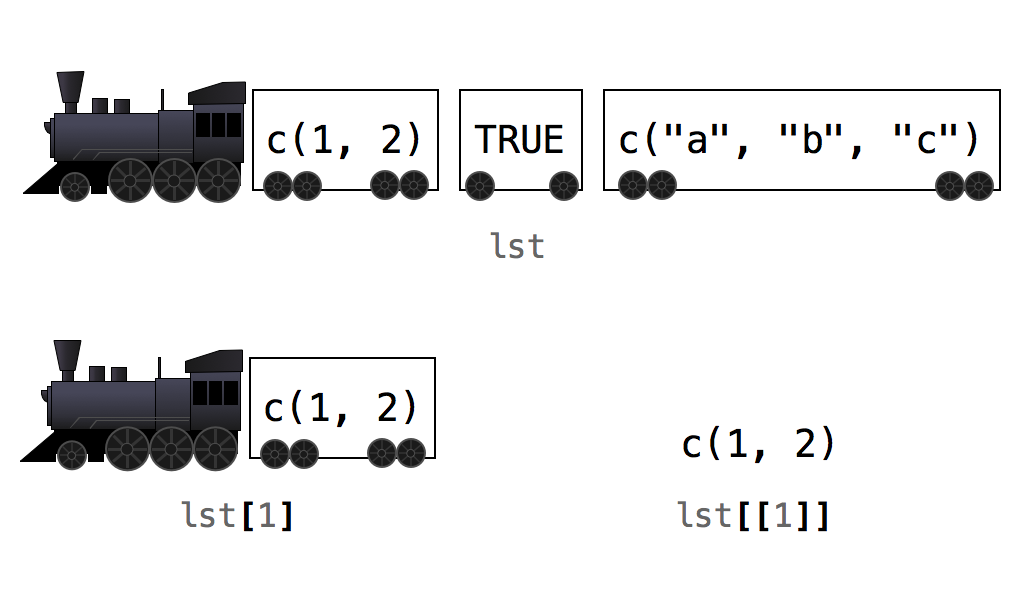

Izdvajanje vrednosti liste

## ✏️ Modifikovanje vrednosti vektora

U R-u možemo **menjati pojedinačne ili više vrednosti u vektoru** pomoću **indeksiranja**.

### 🛠 Primer modifikacije vrednosti u vektoru

```r
vec <- c(0, 0, 0, 0, 0, 0)
vec
```

```
[1] 0 0 0 0 0 0
```

```r
vec[1]
```

```
[1] 0
```

```r
vec[1] <- 1000
vec
```

```
[1] 1000    0    0    0    0    0
```

```r
vec[c(1, 3, 5)] <- c(1, 1, 1)
vec
```

```
[1] 1 0 1 0 1 0
```

## ✏️ Modifikovanje vrednosti Data Frame-a

U R-u možemo **dodavati, menjati i reorganizovati kolone** unutar `Data Frame`-a.

### 🛠 Primer modifikacije `Data Frame`-a

```r
# Učitavanje ugrađenog Data Frame-a
data(mtcars)
# Čuvanje originalnih imena kolona
mtcars_names <- names(mtcars)
# Dodavanje nove kolone sa imenima redova
mtcars$name <- row.names(mtcars)
# Prikaz atributa Data Frame-a
attributes(mtcars)
# Uklanjanje imena redova (postavljanje na NULL)
row.names(mtcars)  <- NULL
# Dodavanje ID kolone (indeksiranje redova)
mtcars$id <- 1:nrow(mtcars)
# Reorganizacija kolona (ID i ime dolaze na početak)
mtcars <- mtcars[, c("id", "name", mtcars_names)]
# Kreiranje logičkog vektora koji označava automobile sa 4 cilindra
four_cyl <- ifelse(mtcars$cyl == 4, TRUE, FALSE)
```

## 🔀 Kontrola toka

Kontrola toka u R-u omogućava **uslovno izvršavanje koda** pomoću **`if`**, **`else if`** i **`else`** blokova.

### Kontrola toka `if-else`

```r
if (logicki uslov) {
  # Deo koda za slucaj TRUE
} else {
  # Deo koda za skucaj FALSE
}
```

### Primer

```r
# y vece od 10?
y = sample(1:20, size = 1)
if (y > 10) {
  print("Vece od 10")
} else {
  print("Manje od 10")
}
```

```
[1] "Vece od 10"
```

## Kontrola toka `else if`

### Kontrola toka `else if`

```r
if (logicki_uslov_1) {
  # Deo koda za slucaj TRUE
} else if (logicki_uslov_2) {
  # Deo koda kada je prvi uslov FALSE
  # ali je drugi    uslov TRUE
} else {
  # Deo koda kada su oba uslova FALSE
}
```

### Primer

```r
# y vece od 1 ali manje od 10?

if (y > 1) {
  print("Vece od 1")
} else if (y < 10) {
  print("vece od 1 ali manje od 10")
} else {
  print("Broj je veci od 10")
}
```

```
[1] "Vece od 1"
```

## 🔄 Petlje

Petlje omogućavaju **ponavljanje izvršavanja koda** dok god su zadovoljeni određeni uslovi.

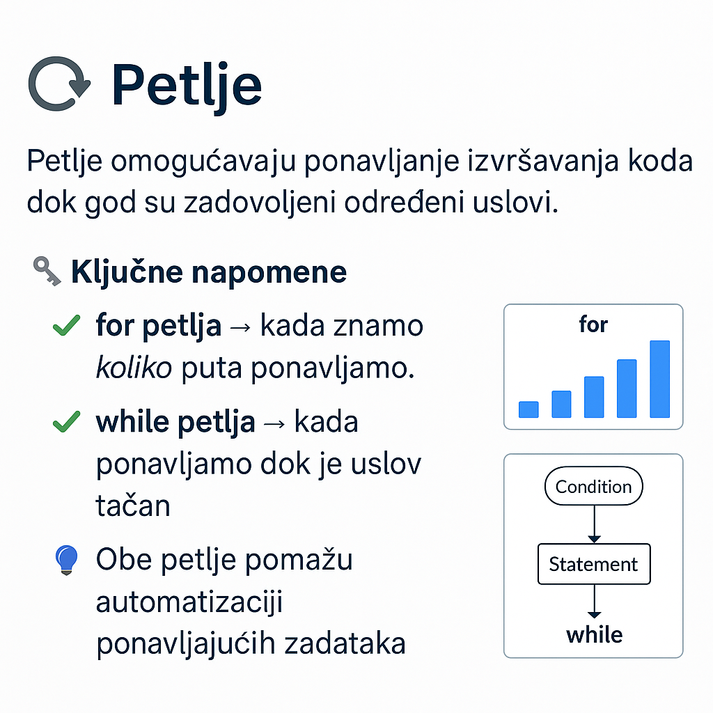

### 🔑 Ključne napomene:

✅ **`for` petlja** se koristi kada znamo **koliko puta treba ponoviti kod**.

✅ **`while` petlja** se koristi kada želimo ponavljanje **dok je uslov tačan**.

✅ **Obe petlje omogućavaju automatizaciju ponavljajućih zadataka**.